# IODS course project

# Chapter 3

Libraries

```r
library(tidyr)
library(dplyr)
library(ggplot2)
library(GGally)
library(corrr)
library(sjPlot)
```

reading data

```r
alc <- read.table("https://raw.githubusercontent.com/KimmoVehkalahti/Helsinki-Open-Data-Science/master/datasets/alc.csv", sep = ",", header = TRUE)

str(alc)
```

```
## 'data.frame':    370 obs. of  35 variables:
##  $ school    : chr  "GP" "GP" "GP" "GP" ...
##  $ sex       : chr  "F" "F" "F" "F" ...
##  $ age       : int  18 17 15 15 16 16 16 17 15 15 ...
##  $ address   : chr  "U" "U" "U" "U" ...
##  $ famsize   : chr  "GT3" "GT3" "LE3" "GT3" ...
##  $ Pstatus   : chr  "A" "T" "T" "T" ...
##  $ Medu      : int  4 1 1 4 3 4 2 4 3 3 ...
##  $ Fedu      : int  4 1 1 2 3 3 2 4 2 4 ...
##  $ Mjob      : chr  "at_home" "at_home" "at_home" "health" ...
##  $ Fjob      : chr  "teacher" "other" "other" "services" ...
##  $ reason    : chr  "course" "course" "other" "home" ...
##  $ guardian  : chr  "mother" "father" "mother" "mother" ...
##  $ traveltime: int  2 1 1 1 1 1 1 2 1 1 ...
##  $ studytime : int  2 2 2 3 2 2 2 2 2 2 ...
```

[output cut: 21 more lines]

```r
colnames(alc)
```

```
##  [1] "school"     "sex"        "age"        "address"    "famsize"
##  [6] "Pstatus"    "Medu"       "Fedu"       "Mjob"       "Fjob"
## [11] "reason"     "guardian"   "traveltime" "studytime"  "schoolsup"
## [16] "famsup"     "activities" "nursery"    "higher"     "internet"
## [21] "romantic"   "famrel"     "freetime"   "goout"      "Dalc"
## [26] "Walc"       "health"     "failures"   "paid"       "absences"
## [31] "G1"         "G2"         "G3"         "alc_use"    "high_use"
```

The data has 370 obs. of 35 variables with a lot of different measures. Including alcohol use of students in secondary education of two Portuguese schools.

My hypothesis is that high freetime has a positive correlation with high alcohol use, I have the same hypothesis for absences. I’m guessing a negative correlation to alcohol if student wants to reach higher education level. I’m also hypothesising a negative correlation with having a romantic relationship

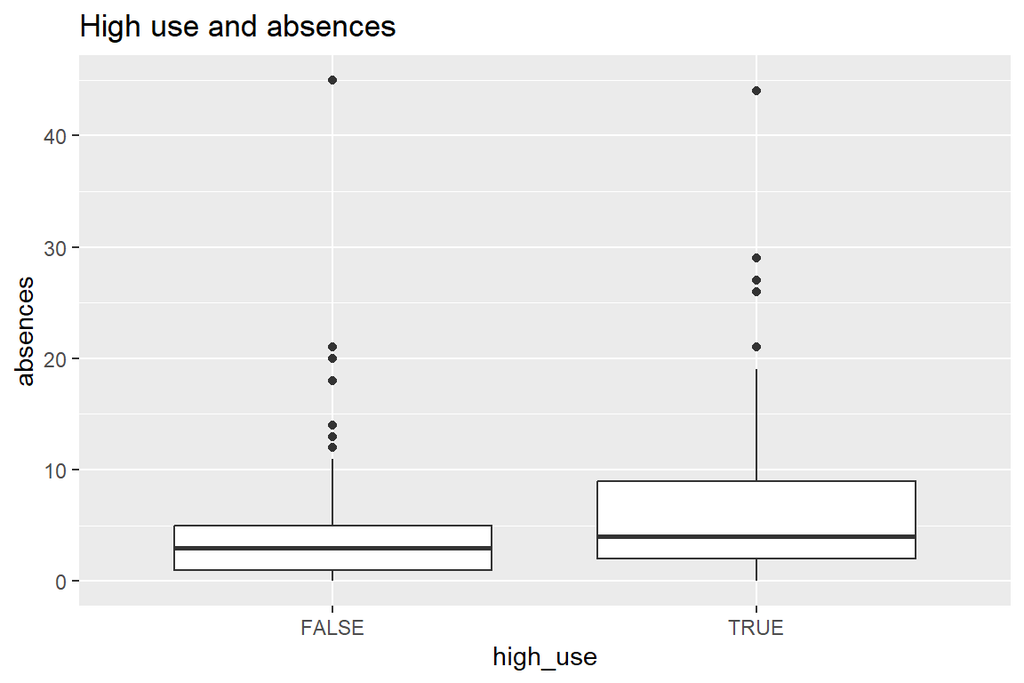

```r
g2 <- ggplot(alc, aes(x = high_use, y = absences,))

g2 + geom_boxplot() + ggtitle("High use and absences")
```

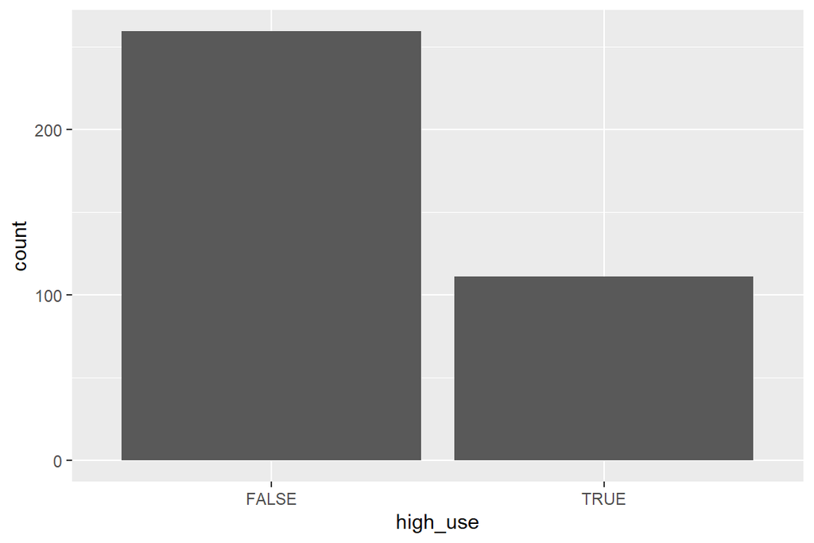

```r
g1 <- ggplot(data = alc, aes(x = high_use))

g1 + geom_bar(aes(fill = absences))
```

```r
tab_xtab(var.row = alc$high_use, var.col = alc$ab,
         title = "Title", show.row.prc = TRUE)
```

Title

| high_use | ab |  |  |  |  |  |  |  |  |  |  |  |  |  |  |  |  |  |  |  |  |  |  |  |  |  | Total |  |
| --- | --- | --- | --- | --- | --- | --- | --- | --- | --- | --- | --- | --- | --- | --- | --- | --- | --- | --- | --- | --- | --- | --- | --- | --- | --- | --- | --- | --- |
|  | 0 | 1 | 2 | 3 | 4 | 5 | 6 | 7 | 8 | 9 | 10 | 11 | 12 | 13 | 14 | 16 | 17 | 18 | 19 | 20 | 21 | 26 | 27 | 29 | 44 | 45 |  |  |
| FALSE | 50 19.3 % | 37 14.3 % | 40 15.4 % | 31 12 % | 24 9.3 % | 16 6.2 % | 16 6.2 % | 9 3.5 % | 14 5.4 % | 5 1.9 % | 5 1.9 % | 2 0.8 % | 3 1.2 % | 1 0.4 % | 1 0.4 % | 0 0 % | 0 0 % | 1 0.4 % | 0 0 % | 2 0.8 % | 1 0.4 % | 0 0 % | 0 0 % | 0 0 % | 0 0 % | 1 0.4 % |  | 259 100 % |
| TRUE | 13 11.7 % | 13 11.7 % | 16 14.4 % | 7 6.3 % | 11 9.9 % | 6 5.4 % | 5 4.5 % | 3 2.7 % | 6 5.4 % | 6 5.4 % | 2 1.8 % | 3 2.7 % | 4 3.6 % | 1 0.9 % | 6 5.4 % | 1 0.9 % | 1 0.9 % | 1 0.9 % | 1 0.9 % | 0 0 % | 1 0.9 % | 1 0.9 % | 1 0.9 % | 1 0.9 % | 1 0.9 % | 0 0 % | 111 100 % |  |
| Total | 63 17 % | 50 13.5 % | 56 15.1 % | 38 10.3 % | 35 9.5 % | 22 5.9 % | 21 5.7 % | 12 3.2 % | 20 5.4 % | 11 3 % | 7 1.9 % | 5 1.4 % | 7 1.9 % | 2 0.5 % | 7 1.9 % | 1 0.3 % | 1 0.3 % | 2 0.5 % | 1 0.3 % | 2 0.5 % | 2 0.5 % | 1 0.3 % | 1 0.3 % | 1 0.3 % | 1 0.3 % | 1 0.3 % | 370 100 % |  |

```r
table(high_use = alc$high_use, absences = alc$absences) %>% prop.table() %>% addmargins()
```

```
##         absences
## high_use           0           1           2           3           4
##    FALSE 0.135135135 0.100000000 0.108108108 0.083783784 0.064864865
##    TRUE  0.035135135 0.035135135 0.043243243 0.018918919 0.029729730
##    Sum   0.170270270 0.135135135 0.151351351 0.102702703 0.094594595
##         absences
## high_use           5           6           7           8           9
##    FALSE 0.043243243 0.043243243 0.024324324 0.037837838 0.013513514
##    TRUE  0.016216216 0.013513514 0.008108108 0.016216216 0.016216216
##    Sum   0.059459459 0.056756757 0.032432432 0.054054054 0.029729730
##         absences
## high_use          10          11          12          13          14
##    FALSE 0.013513514 0.005405405 0.008108108 0.002702703 0.002702703
##    TRUE  0.005405405 0.008108108 0.010810811 0.002702703 0.016216216
##    Sum   0.018918919 0.013513514 0.018918919 0.005405405 0.018918919
##         absences
## high_use          16          17          18          19          20
##    FALSE 0.000000000 0.000000000 0.002702703 0.000000000 0.005405405
##    TRUE  0.002702703 0.002702703 0.002702703 0.002702703 0.000000000
##    Sum   0.002702703 0.002702703 0.005405405 0.002702703 0.005405405
##         absences
## high_use          21          26          27          29          44
##    FALSE 0.002702703 0.000000000 0.000000000 0.000000000 0.000000000
##    TRUE  0.002702703 0.002702703 0.002702703 0.002702703 0.002702703
##    Sum   0.005405405 0.002702703 0.002702703 0.002702703 0.002702703
##         absences
## high_use          45         Sum
##    FALSE 0.002702703 0.700000000
##    TRUE  0.000000000 0.300000000
##    Sum   0.002702703 1.000000000
```

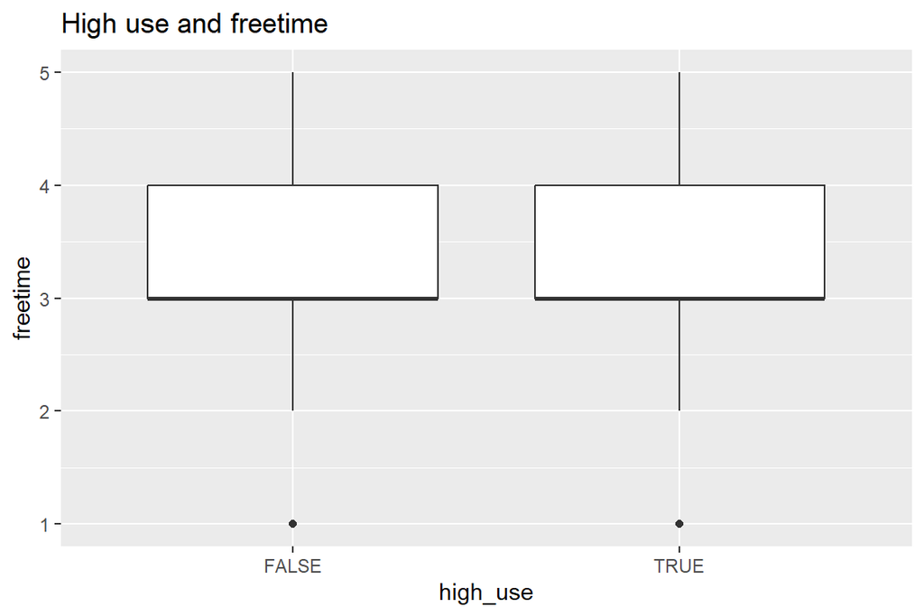

```r
g2 <- ggplot(alc, aes(x = high_use, y = freetime,))

g2 + geom_boxplot() + ggtitle("High use and freetime")
```

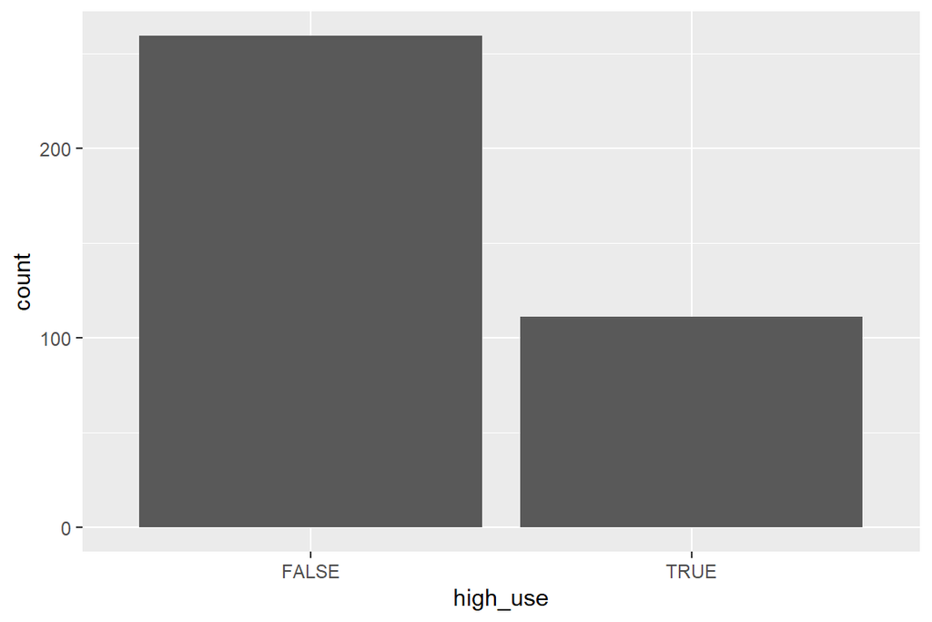

```r
g1 <- ggplot(data = alc, aes(x = high_use))

g1 + geom_bar(aes(fill = absences))
```

```r
tab_xtab(var.row = alc$high_use, var.col = alc$freetime,
         title = "Title", show.row.prc = TRUE)
```

Title

| high_use | freetime |  |  |  |  | Total |  |
| --- | --- | --- | --- | --- | --- | --- | --- |
|  | 1 | 2 | 3 | 4 | 5 |  |  |
| FALSE | 15 5.8 % | 46 17.8 % | 112 43.2 % | 65 25.1 % | 21 8.1 % |  | 259 100 % |
| TRUE | 2 1.8 % | 14 12.6 % | 40 36 % | 40 36 % | 15 13.5 % | 111 100 % |  |
| Total | 17 4.6 % | 60 16.2 % | 152 41.1 % | 105 28.4 % | 36 9.7 % | 370 100 % |  |

```r
table(high_use = alc$high_use, freetime = alc$freetime) %>% prop.table() %>% addmargins()
```

```
##         freetime
## high_use           1           2           3           4           5
##    FALSE 0.040540541 0.124324324 0.302702703 0.175675676 0.056756757
##    TRUE  0.005405405 0.037837838 0.108108108 0.108108108 0.040540541
##    Sum   0.045945946 0.162162162 0.410810811 0.283783784 0.097297297
##         freetime
## high_use         Sum
##    FALSE 0.700000000
##    TRUE  0.300000000
##    Sum   1.000000000
```

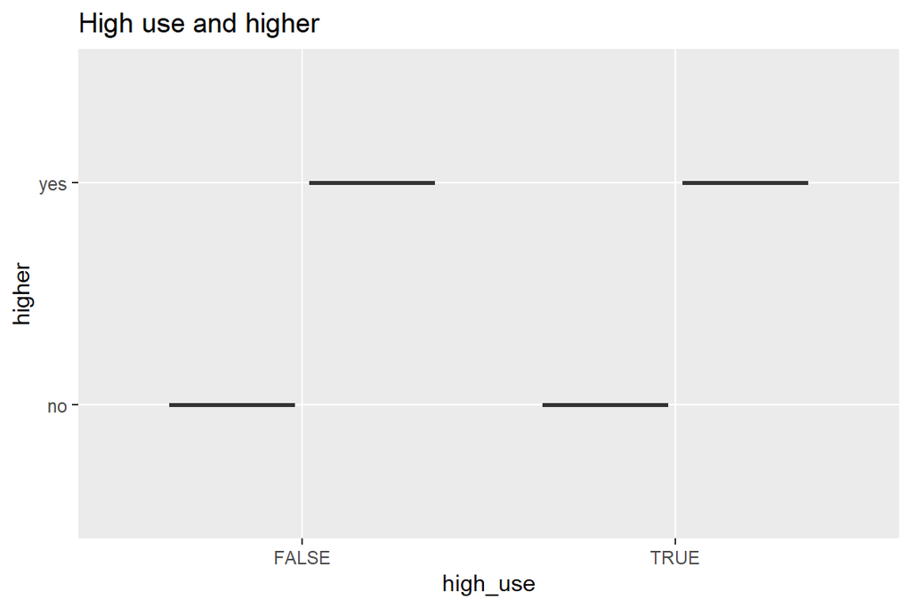

```r
g2 <- ggplot(alc, aes(x = high_use, y = higher,))

g2 + geom_boxplot() + ggtitle("High use and higher")
```

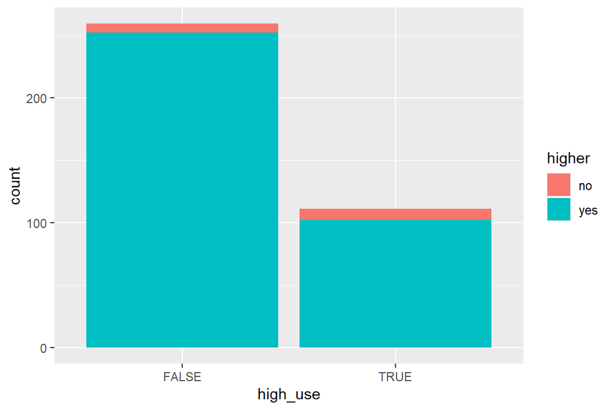

```r
g1 <- ggplot(data = alc, aes(x = high_use))

g1 + geom_bar(aes(fill = higher))
```

```r
tab_xtab(var.row = alc$high_use, var.col = alc$higher,
         title = "Title", show.row.prc = TRUE)
```

Title

| high_use | higher |  | Total |  |
| --- | --- | --- | --- | --- |
|  | no | yes |  |  |
| FALSE | 7 2.7 % | 252 97.3 % |  | 259 100 % |
| TRUE | 9 8.1 % | 102 91.9 % | 111 100 % |  |
| Total | 16 4.3 % | 354 95.7 % | 370 100 % |  |

```r
table(high_use = alc$high_use, higher = alc$higher) %>% prop.table() %>% addmargins()
```

```
##         higher
## high_use         no        yes        Sum
##    FALSE 0.01891892 0.68108108 0.70000000
##    TRUE  0.02432432 0.27567568 0.30000000
##    Sum   0.04324324 0.95675676 1.00000000
```

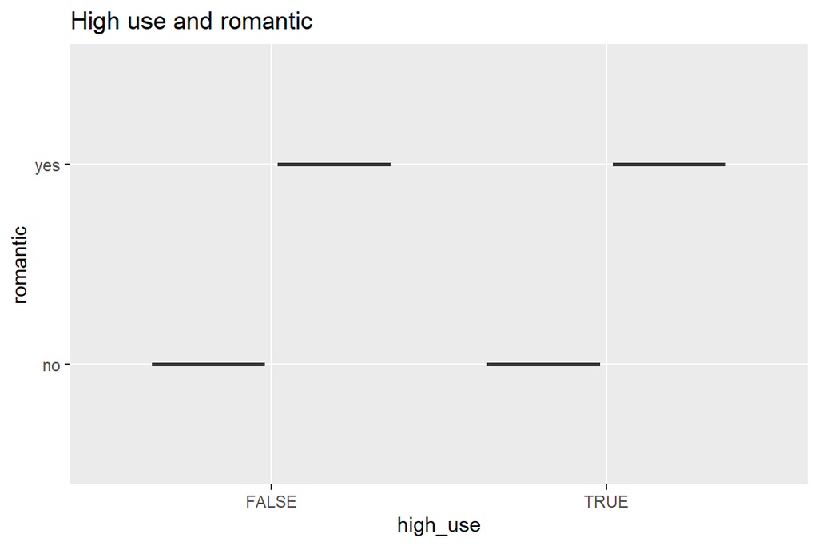

```r
g2 <- ggplot(alc, aes(x = high_use, y = romantic,))

g2 + geom_boxplot() + ggtitle("High use and romantic")
```

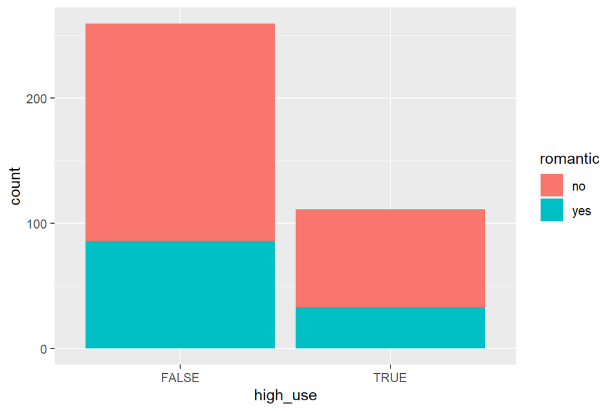

```r
g1 <- ggplot(data = alc, aes(x = high_use))

g1 + geom_bar(aes(fill = romantic))
```

```r
tab_xtab(var.row = alc$high_use, var.col = alc$romantic,
         title = "Title", show.row.prc = TRUE)
```

Title

| high_use | romantic |  | Total |  |
| --- | --- | --- | --- | --- |
|  | no | yes |  |  |
| FALSE | 173 66.8 % | 86 33.2 % |  | 259 100 % |
| TRUE | 78 70.3 % | 33 29.7 % | 111 100 % |  |
| Total | 251 67.8 % | 119 32.2 % | 370 100 % |  |

```r
table(high_use = alc$high_use, higher = alc$romantic) %>% prop.table() %>% addmargins()
```

```
##         higher
## high_use         no        yes        Sum
##    FALSE 0.46756757 0.23243243 0.70000000
##    TRUE  0.21081081 0.08918919 0.30000000
##    Sum   0.67837838 0.32162162 1.00000000
```

```r
test <- c("high_use","absences", "freetime", "higher", "romantic")

data2 <- select(alc, one_of(test))

glimpse(test)
```

```
##  chr [1:5] "high_use" "absences" "freetime" "higher" "romantic"
```

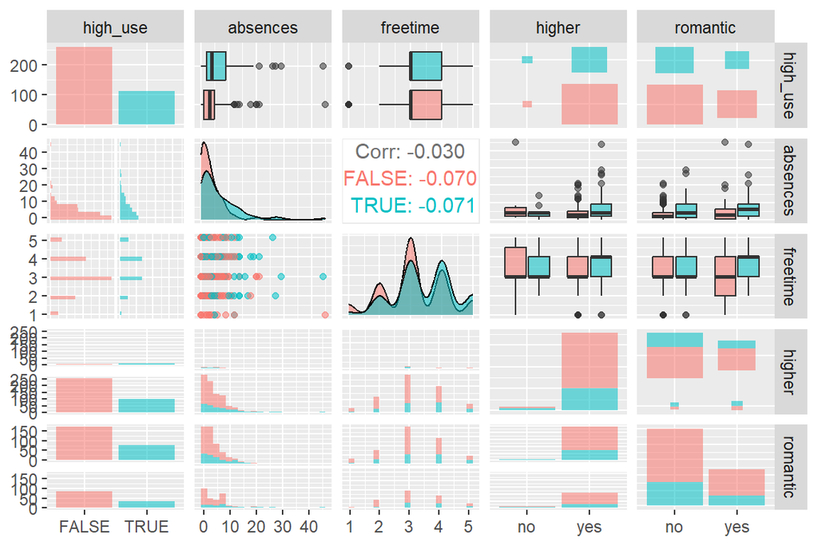

```r
p <- ggpairs(data2, mapping = aes(col = high_use, alpha = 0.3), lower = list(combo = wrap("facethist", bins = 20)))

p
```